# Simulation Project

Holly Michalak

12/8/2019

## Introduction

Sevens is a game played with six dice for a specified number of rounds. The player rolls six dice and must remove the pairs that total to seven. The player can then choose to keep the remaining dice, in which case the total of those dice is their score for the round. Or the player can roll up to two more times, removing pairs of dice that total to seven after every roll. All other players must roll their dice as many times as the first player or fewer.

This simulation explores the distribution of a player’s score according to some simple rules and to estimate the probability of winning a simplified game with a particular strategy. The following are (several) simplifying assumptions that are made for the purposes of this simulation:

- There is one round per game (i.e. there are no rounds, only games)
- The “opponent” will be assigned a random strategy
- There are two players: Strategy Player and Random Player
- The strategy player always rolls first and random player does not consider the score of the strategy player  
  This simulation will answer these questions:
- What is the distribution of a players score when the player always rolls once? Twice? Three times?
- What is the probability of the strategy player winning against a player who always rolls once? Who always rolls the same number of times as the strategy player? Who always rolls a random number of times (under the constraint that it is less than or equal to the number of times the first player rolled)?

## Methods

In order to simulate the distribution of score if a player always rolls once, the code must simulate a roll of 6 dice, remove the pairs that total to seven, and return the score. The distribution of score when rolling twice or three times is similar and simply requires that the number of dice left is preserved from the previous roll. The code then generates another roll of however many fice are left over. Simulating each of these 10,000 times gives a sampling distribution for each number of rolls.

To estimate the probability of the strategy player winning, the decision rule must be incorporated. The strategy player will make the choice to roll again or keep their score based on the expected value of the dice they have left, which are indicated below:

$$\mathbb{E}[roll\ 6\ dice ] = 21$$
$$\mathbb{E}[roll\ 4\ dice ] = 14$$
$$\mathbb{E}[roll\ 2\ dice ] = 7$$

For example, if two dice must be removed the player has four left. If the player’s score is less than 14, the player will roll again hoping to get a better score. If the player’s score is greater than or equal to 14, the player will keep their score for that round. This “strategy,” will be tested against a player who always rolls just once, who always rolls the same number of times as the first player, and who randomly chooses how many times to roll (under the restriction tha it must be less than or equal to the number of times the first player rolled).

## Results

The results for the distribution of score by the different rolls were not surprising. All three distributions are skewed to the right. The mean and variance decrease as the number of rolls increases:

Roll Once: mean = 10.5904, var = 49.3007579  
Roll Twice: mean = 6.7305, var = 28.092479  
Roll Three Times: mean = 4.9108, var = 19.1481582

Seven is the most likely total of a pair of dice, so rolling your dice again in this game is a big risk. This is supported by these distributions.

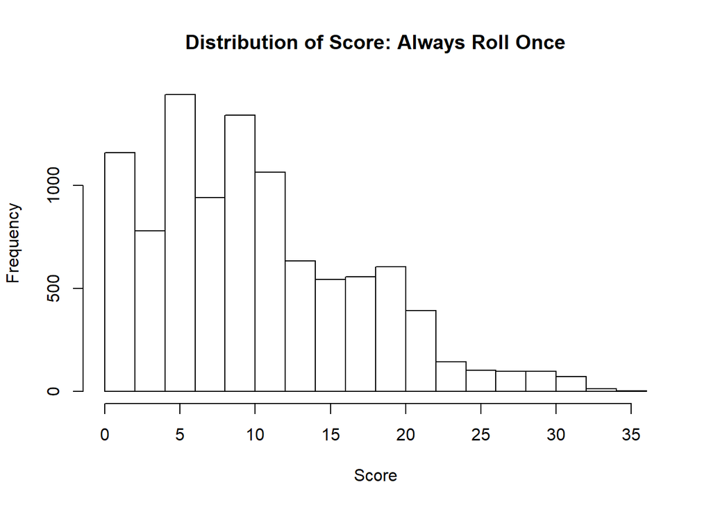

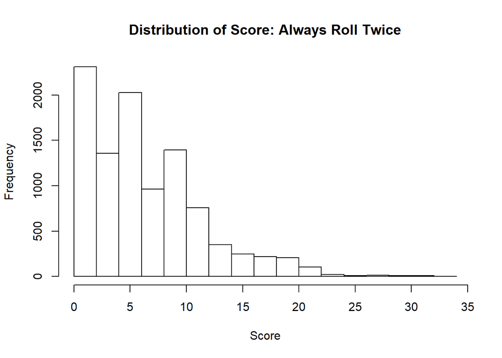

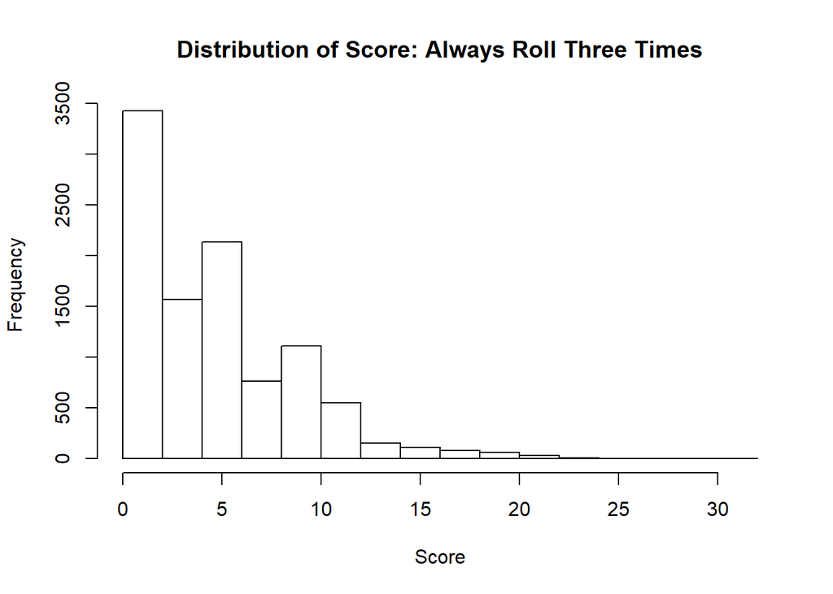

Random Player Rolls Same Number of Times as Strategy Player: 0.513  
Random Player Rolls Once Every Time: 0.461  
Random Player Rolls Random Number of Times: 0.508

## Conclusions and Future Work

The simplifying assumptions made for this simulation render the results essentially inapplicable to a real game of sevens. Perhaps the most important aspect that is left out is that the player does not consider the other player’s score when deciding whether to roll the dice again. If you are winning by a large margin, you might be more willing to take a risk and roll the dice again, whereas you may be more conservative if your scores are close. Future work on this might consider the score differential when making the decision to roll in combination with a threshold. Other future work might include increasing the score threshold that causes the player to roll again, or giving the second player an actual strategy instead of having them roll basically randomly. In order to answer the question of when to roll again, your score your opponent’s score must both be considered.

## Appendix

```r
library(tidyverse)

#expected value of sum of n rolls of dice

exp_sum <- function(n){
  n_sum <- (21/6)*n
  return(n_sum)
}

#what's the distribution of score when you never roll again?

sevens_always_once <- function(){

  #roll six dice
  rolls <- sample(1:6, 6, replace = TRUE)
  onesix <- c(1,6)
  twofive <- c(2,5)
  threefour <- c(3,4)

  #check for dice that total to seven

  ones <- sum(rolls == 1)
  sixes <- sum(rolls == 6)

  #if there's the same number of each, remove all of them

  #only need to go through this if there is a one or a six
  if(ones != 0 & sixes != 0){
    if(ones %% sixes == 0){
      rolls <- rolls[which(rolls != 6 & rolls != 1)]
      }else{

        diff <- abs(ones-sixes)
  #number of pairs to remove

        num_pairs <- max(ones, sixes) - diff
  #go through this as many times as there are pairs to remove

          for(i in 1:num_pairs){
            if(all(onesix %in% rolls)){
              rolls <- rolls[-match(onesix, rolls)]
                    }
                  }
                }
              }


  twos <- sum(rolls == 2)
  fives <- sum(rolls == 5)

  #only need to go through this if there is a two or a five
  if(twos != 0 & fives != 0){

   if(twos %% fives == 0){
    rolls <- rolls[which(rolls != 2 & rolls != 5)]
      }else{

  diff <- abs(twos-fives)
  #number of pairs to remove
  num_pairs <- max(twos, fives) - diff

  #go through this as many times as there are pairs to remove
    for(i in 1:num_pairs){
    if(all(twofive %in% rolls)){
    rolls <- rolls[-match(twofive, rolls)]
      }
    }
  }
}


  threes <- sum(rolls == 3)
  fours <- sum(rolls == 4)
  #only need to go through this if there is a 3 or a 4
  if(threes != 0 & fours != 0){
  if(threes %% fours == 0){
  rolls <- rolls[which(rolls != 3 & rolls != 4)]

  }else{
    diff <- abs(threes-fours)
    num_pairs <- max(threes, fours) - diff
        for(i in 1:num_pairs){

            if(all(threefour %in% rolls)){
            rolls <- rolls[-match(threefour, rolls)]
           }
        }
     }
  }


  dice_left <- length(rolls)
  curr_score <- sum(rolls)
  out <- c(curr_score, dice_left)
  return(out)
}


sevens_always_once()
roll_once <- replicate(10000,sevens_always_once())
roll_once <- data.frame(t(roll_once))
names(roll_once) <- c("Score", "Dice_Left")


sevens_always_twice <- function(){
first_roll <- sevens_always_once()

  rolls <- sample(1:6, first_roll[2], replace = TRUE)

  onesix <- c(1,6)
  twofive <- c(2,5)
  threefour <- c(3,4)



   #check for dice that total to seven

  ones <- sum(rolls == 1)
  sixes <- sum(rolls == 6)

  #if there's the same number of each, remove all of them

  #only need to go through this if there is a one or a six
  if(ones != 0 & sixes != 0){
 if(ones %% sixes == 0){
  rolls <- rolls[which(rolls != 6 & rolls != 1)]
  }else{

  diff <- abs(ones-sixes)
  #number of pairs to remove
  num_pairs <- max(ones, sixes) - diff
  #go through this as many times as there are pairs to remove
    for(i in 1:num_pairs){
    if(all(onesix %in% rolls)){
    rolls <- rolls[-match(onesix, rolls)]
    }
  }
  }
  }


  twos <- sum(rolls == 2)
  fives <- sum(rolls == 5)

  #only need to go through this if there is a two or a five
  if(twos != 0 & fives != 0){

   if(twos %% fives == 0){
  rolls <- rolls[which(rolls != 2 & rolls != 5)]
  }else{

  diff <- abs(twos-fives)
  #number of pairs to remove
  num_pairs <- max(twos, fives) - diff

  #go through this as many times as there are pairs to remove
    for(i in 1:num_pairs){
    if(all(twofive %in% rolls)){
    rolls <- rolls[-match(twofive, rolls)]
      }
    }
  }
  }


  threes <- sum(rolls == 3)
  fours <- sum(rolls == 4)
  #only need to go through this if there is a 3 or a 4
  if(threes != 0 & fours != 0){
  if(threes %% fours == 0){
  rolls <- rolls[which(rolls != 3 & rolls != 4)]

  }else{
    diff <- abs(threes-fours)
    num_pairs <- max(threes, fours) - diff
        for(i in 1:num_pairs){

            if(all(threefour %in% rolls)){
            rolls <- rolls[-match(threefour, rolls)]
           }
        }
   }
}

  curr_score <- sum(rolls)
  dice_left <- length(rolls)
  out <- c( curr_score, dice_left)
  return(out)

}

sevens_always_twice()
roll_twice <- replicate(10000,sevens_always_twice())
roll_twice <- data.frame(t(roll_twice))
names(roll_twice) <- c("Score", "Dice_Left")



sevens_always_thrice <- function(){
  prev_rolls <- sevens_always_twice()

  rolls <- sample(1:6, prev_rolls[2], replace=TRUE)
    onesix <- c(1,6)
  twofive <- c(2,5)
  threefour <- c(3,4)



   #check for dice that total to seven

  ones <- sum(rolls == 1)
  sixes <- sum(rolls == 6)

  #if there's the same number of each, remove all of them

  #only need to go through this if there is a one or a six
  if(ones != 0 & sixes != 0){
 if(ones %% sixes == 0){
  rolls <- rolls[which(rolls != 6 & rolls != 1)]
  }else{

  diff <- abs(ones-sixes)
  #number of pairs to remove
  num_pairs <- max(ones, sixes) - diff
  #go through this as many times as there are pairs to remove
    for(i in 1:num_pairs){
    if(all(onesix %in% rolls)){
    rolls <- rolls[-match(onesix, rolls)]
    }
  }
  }
  }


  twos <- sum(rolls == 2)
  fives <- sum(rolls == 5)

  #only need to go through this if there is a two or a five
  if(twos != 0 & fives != 0){

   if(twos %% fives == 0){
  rolls <- rolls[which(rolls != 2 & rolls != 5)]
  }else{

  diff <- abs(twos-fives)
  #number of pairs to remove
  num_pairs <- max(twos, fives) - diff

  #go through this as many times as there are pairs to remove
    for(i in 1:num_pairs){
    if(all(twofive %in% rolls)){
    rolls <- rolls[-match(twofive, rolls)]
      }
    }
  }
  }


  threes <- sum(rolls == 3)
  fours <- sum(rolls == 4)
  #only need to go through this if there is a 3 or a 4
  if(threes != 0 & fours != 0){
  if(threes %% fours == 0){
  rolls <- rolls[which(rolls != 3 & rolls != 4)]

  }else{
    diff <- abs(threes-fours)
    num_pairs <- max(threes, fours) - diff
        for(i in 1:num_pairs){

            if(all(threefour %in% rolls)){
            rolls <- rolls[-match(threefour, rolls)]
           }
        }
   }
}

  curr_score <- sum(rolls)
  dice_left <- length(rolls)
  out <- c(curr_score, dice_left)
  return(out)
}


roll_thrice <- replicate(10000,sevens_always_thrice())
roll_thrice <- data.frame(t(roll_thrice))
names(roll_thrice) <- c("Score", "Dice_Left")
```

```r
check_roll_one <- function(rolls){

  try_again <- FALSE
  round_over <- FALSE

  onesix <- c(1,6)
  twofive <- c(2,5)
  threefour <- c(3,4)

  #check for dice that total to seven

  ones <- sum(rolls == 1)
  sixes <- sum(rolls == 6)

  #if there's the same number of each, remove all of them
  #only need to go through this if there is a one or a six
  if(ones != 0 & sixes != 0){
 if(ones %% sixes == 0){
  rolls <- rolls[which(rolls != 6 & rolls != 1)]
  }else{

  diff <- abs(ones-sixes)
  #number of pairs to remove
  num_pairs <- max(ones, sixes) - diff
  #go through this as many times as there are pairs to remove
    for(i in 1:num_pairs){
    if(all(onesix %in% rolls)){
    rolls <- rolls[-match(onesix, rolls)]
    }
  }
  }
  }


  twos <- sum(rolls == 2)
  fives <- sum(rolls == 5)

  #only need to go through this if there is a two or a five
  if(twos != 0 & fives != 0){

   if(twos %% fives == 0){
  rolls <- rolls[which(rolls != 2 & rolls != 5)]
  }else{

  diff <- abs(twos-fives)
  #number of pairs to remove
  num_pairs <- max(twos, fives) - diff

  #go through this as many times as there are pairs to remove
    for(i in 1:num_pairs){
    if(all(twofive %in% rolls)){
    rolls <- rolls[-match(twofive, rolls)]
      }
    }
  }
  }


  threes <- sum(rolls == 3)
  fours <- sum(rolls == 4)
  #only need to go through this if there is a 3 or a 4
  if(threes != 0 & fours != 0){
  if(threes %% fours == 0){
  rolls <- rolls[which(rolls != 3 & rolls != 4)]

  }else{
    diff <- abs(threes-fours)
    num_pairs <- max(threes, fours) - diff
        for(i in 1:num_pairs){

            if(all(threefour %in% rolls)){
            rolls <- rolls[-match(threefour, rolls)]
           }
        }
   }
}


  dice_left <- length(rolls)
  curr_score <- sum(rolls)
  round_score <- curr_score

  if(dice_left == 6 & curr_score >= 21){
    try_again <- FALSE
    rolls_allowed <- 1
  }else if (dice_left == 6 & curr_score < 21){
    try_again <- TRUE
    rolls_allowed <- 2
  }else if (dice_left == 4 & curr_score >= 14){
    try_again <- FALSE
    rolls_allowed <- 1
  }else if (dice_left == 4 & curr_score < 14){
    try_again <- TRUE
    round_score <- curr_score
    rolls_allowed <- 2
  }else if (dice_left == 2 & curr_score >= 7 ){
    try_again <- FALSE
    rolls_allowed <- 1
  }else if (dice_left == 2 & curr_score < 7){
    try_again <- TRUE
    rolls_allowed <- 2
  }else{
    try_again <- FALSE
    round_score <- curr_score
    rolls_allowed <- 1
  }

  ret_list <- list(rolls, dice_left, try_again, round_score, rolls_allowed)
  return(ret_list)
}


rolls <- sample(1:6, 6, replace=TRUE)


check_roll_two <- function(num_dice){

  rolls <- sample(1:6, num_dice, replace=TRUE)
 #cat("second roll is", rolls)
  onesix <- c(1,6)
  twofive <- c(2,5)
  threefour <- c(3,4)

  #check for dice that total to seven

  ones <- sum(rolls == 1)
  sixes <- sum(rolls == 6)

  #if there's the same number of each, remove all of them
  #only need to go through this if there is a one or a six
  if(ones != 0 & sixes != 0){
 if(ones %% sixes == 0){
  rolls <- rolls[which(rolls != 6 & rolls != 1)]
  }else{

  diff <- abs(ones-sixes)
  #number of pairs to remove
  num_pairs <- max(ones, sixes) - diff
  #go through this as many times as there are pairs to remove
    for(i in 1:num_pairs){
    if(all(onesix %in% rolls)){
    rolls <- rolls[-match(onesix, rolls)]
    }
  }
  }
  }


  twos <- sum(rolls == 2)
  fives <- sum(rolls == 5)

  #only need to go through this if there is a two or a five
  if(twos != 0 & fives != 0){

   if(twos %% fives == 0){
  rolls <- rolls[which(rolls != 2 & rolls != 5)]
  }else{

  diff <- abs(twos-fives)
  #number of pairs to remove
  num_pairs <- max(twos, fives) - diff

  #go through this as many times as there are pairs to remove
    for(i in 1:num_pairs){
    if(all(twofive %in% rolls)){
    rolls <- rolls[-match(twofive, rolls)]
      }
    }
  }
  }


  threes <- sum(rolls == 3)
  fours <- sum(rolls == 4)
  #only need to go through this if there is a 3 or a 4
  if(threes != 0 & fours != 0){
  if(threes %% fours == 0){
  rolls <- rolls[which(rolls != 3 & rolls != 4)]

  }else{
    diff <- abs(threes-fours)
    num_pairs <- max(threes, fours) - diff
        for(i in 1:num_pairs){

            if(all(threefour %in% rolls)){
            rolls <- rolls[-match(threefour, rolls)]
           }
        }
   }
}



  dice_left <- length(rolls)
  curr_score <- sum(rolls)
  round_score <- curr_score

if (dice_left == 4 & curr_score >= 14){
    try_again <- FALSE
    rolls_allowed <- 2
  }else if (dice_left == 4 & curr_score < 14){
    try_again <- TRUE
    round_score <- curr_score
    rolls_allowed <- 3
  }else if (dice_left == 2 & curr_score >= 7 ){
    try_again <- FALSE
    rolls_allowed <- 2
  }else if (dice_left == 2 & curr_score < 7){
    try_again <- TRUE
    rolls_allowed <- 3
  }else{
    try_again <- FALSE
    round_score <- curr_score
    rolls_allowed <- 2
  }


  ret_list <- list(rolls, dice_left, try_again, round_score, rolls_allowed)
  return(ret_list)

}

check_roll_three <- function(num_dice){

  rolls <- sample(1:6, num_dice, replace = TRUE)
  rolls_allowed <- 3
  #cat("third roll is", rolls)
onesix <- c(1,6)
  twofive <- c(2,5)
  threefour <- c(3,4)

  #check for dice that total to seven

  ones <- sum(rolls == 1)
  sixes <- sum(rolls == 6)

  #if there's the same number of each, remove all of them
  #only need to go through this if there is a one or a six
  if(ones != 0 & sixes != 0){
 if(ones %% sixes == 0){
  rolls <- rolls[which(rolls != 6 & rolls != 1)]
  }else{

  diff <- abs(ones-sixes)
  #number of pairs to remove
  num_pairs <- max(ones, sixes) - diff
  #go through this as many times as there are pairs to remove
    for(i in 1:num_pairs){
    if(all(onesix %in% rolls)){
    rolls <- rolls[-match(onesix, rolls)]
    }
  }
  }
  }


  twos <- sum(rolls == 2)
  fives <- sum(rolls == 5)

  #only need to go through this if there is a two or a five
  if(twos != 0 & fives != 0){

   if(twos %% fives == 0){
  rolls <- rolls[which(rolls != 2 & rolls != 5)]
  }else{
```

```r
  diff <- abs(twos-fives)
  #number of pairs to remove
  num_pairs <- max(twos, fives) - diff

  #go through this as many times as there are pairs to remove
    for(i in 1:num_pairs){
    if(all(twofive %in% rolls)){
    rolls <- rolls[-match(twofive, rolls)]
      }
    }
  }
  }


  threes <- sum(rolls == 3)
  fours <- sum(rolls == 4)
  #only need to go through this if there is a 3 or a 4
  if(threes != 0 & fours != 0){
  if(threes %% fours == 0){
  rolls <- rolls[which(rolls != 3 & rolls != 4)]

  }else{
    diff <- abs(threes-fours)
    num_pairs <- max(threes, fours) - diff
        for(i in 1:num_pairs){

            if(all(threefour %in% rolls)){
            rolls <- rolls[-match(threefour, rolls)]
           }
        }
   }
}





  dice_left <- length(rolls)
  curr_score <- sum(rolls)
  round_score <- curr_score


  ret_list <- list(rolls, curr_score, rolls_allowed)
  return(ret_list)

}


#function to simulate this whole thing
#start with one roll

exp_value <- function(){

dice <- sample(1:6, 6, replace=T)
#print(dice)

first_roll <- check_roll_one(dice)
names(first_roll) <- c("roll", "dice_left","try_again", "score", "rolls_allowed")

#if you decide to roll a second time
if(first_roll$try_again == TRUE){
  #print("rolling again")
  second_roll <- check_roll_two(first_roll$dice_left)
  names(second_roll) <- c("roll", "dice_left","try_again", "score", "rolls_allowed")

  #if you decide to roll a third time
  if(second_roll$try_again == TRUE){
   # print("rolling thrice")
    third_roll <- check_roll_three(second_roll$dice_left)
    names(third_roll) <- c("roll", "current_score", "rolls_allowed")
    out <- c(third_roll$current_score, third_roll$rolls_allowed)
    return(out)
  }else{
    #print("rolled twice")
    out <- c( second_roll$score, second_roll$rolls_allowed)
    return(out)
  }

}else{
  #print("only one roll")
  out <- c(first_roll$score, first_roll$rolls_allowed)
  return(out)
}

}

library(purrr)
#need opponent rolls
out <- exp_value()

sim <- replicate(1000, exp_value())
newlist <- data.frame(t(sim))

names(newlist) <- c("score","rolls_allowed")


#second player rolls this many times

opp_rollone <- function(rolls){
  rolls <- sample(1:6, 6, replace=TRUE)
  onesix <- c(1,6)
  twofive <- c(2,5)
  threefour <- c(3,4)

  #check for dice that total to seven

  ones <- sum(rolls == 1)
  sixes <- sum(rolls == 6)

  #if there's the same number of each, remove all of them
  #only need to go through this if there is a one or a six
  if(ones != 0 & sixes != 0){
 if(ones %% sixes == 0){
  rolls <- rolls[which(rolls != 6 & rolls != 1)]
  }else{

  diff <- abs(ones-sixes)
  #number of pairs to remove
  num_pairs <- max(ones, sixes) - diff
  #go through this as many times as there are pairs to remove
    for(i in 1:num_pairs){
    if(all(onesix %in% rolls)){
    rolls <- rolls[-match(onesix, rolls)]
    }
  }
  }
  }


  twos <- sum(rolls == 2)
  fives <- sum(rolls == 5)

  #only need to go through this if there is a two or a five
  if(twos != 0 & fives != 0){

   if(twos %% fives == 0){
  rolls <- rolls[which(rolls != 2 & rolls != 5)]
  }else{

  diff <- abs(twos-fives)
  #number of pairs to remove
  num_pairs <- max(twos, fives) - diff

  #go through this as many times as there are pairs to remove
    for(i in 1:num_pairs){
    if(all(twofive %in% rolls)){
    rolls <- rolls[-match(twofive, rolls)]
      }
    }
  }
  }


  threes <- sum(rolls == 3)
  fours <- sum(rolls == 4)
  #only need to go through this if there is a 3 or a 4
  if(threes != 0 & fours != 0){
  if(threes %% fours == 0){
  rolls <- rolls[which(rolls != 3 & rolls != 4)]

  }else{
    diff <- abs(threes-fours)
    num_pairs <- max(threes, fours) - diff
        for(i in 1:num_pairs){

            if(all(threefour %in% rolls)){
            rolls <- rolls[-match(threefour, rolls)]
           }
        }
   }
}


  dice_left <- length(rolls)
  curr_score <- sum(rolls)
  round_score <- curr_score



  ret_list <- c(dice_left, round_score)
  return(ret_list)


}

opp_rolltwo <- function(dice_left){
  rolls <- sample(1:6, dice_left, replace=TRUE)
  onesix <- c(1,6)
  twofive <- c(2,5)
  threefour <- c(3,4)

  #check for dice that total to seven

  ones <- sum(rolls == 1)
  sixes <- sum(rolls == 6)

  #if there's the same number of each, remove all of them
  #only need to go through this if there is a one or a six
  if(ones != 0 & sixes != 0){
 if(ones %% sixes == 0){
  rolls <- rolls[which(rolls != 6 & rolls != 1)]
  }else{

  diff <- abs(ones-sixes)
  #number of pairs to remove
  num_pairs <- max(ones, sixes) - diff
  #go through this as many times as there are pairs to remove
    for(i in 1:num_pairs){
    if(all(onesix %in% rolls)){
    rolls <- rolls[-match(onesix, rolls)]
    }
  }
  }
  }


  twos <- sum(rolls == 2)
  fives <- sum(rolls == 5)

  #only need to go through this if there is a two or a five
  if(twos != 0 & fives != 0){

   if(twos %% fives == 0){
  rolls <- rolls[which(rolls != 2 & rolls != 5)]
  }else{

  diff <- abs(twos-fives)
  #number of pairs to remove
  num_pairs <- max(twos, fives) - diff

  #go through this as many times as there are pairs to remove
    for(i in 1:num_pairs){
    if(all(twofive %in% rolls)){
    rolls <- rolls[-match(twofive, rolls)]
      }
    }
  }
  }


  threes <- sum(rolls == 3)
  fours <- sum(rolls == 4)
  #only need to go through this if there is a 3 or a 4
  if(threes != 0 & fours != 0){
  if(threes %% fours == 0){
  rolls <- rolls[which(rolls != 3 & rolls != 4)]

  }else{
    diff <- abs(threes-fours)
    num_pairs <- max(threes, fours) - diff
        for(i in 1:num_pairs){

            if(all(threefour %in% rolls)){
            rolls <- rolls[-match(threefour, rolls)]
           }
        }
   }
}


  dice_left <- length(rolls)
  curr_score <- sum(rolls)
  round_score <- curr_score



  ret_list <- c(dice_left, round_score)
  return(ret_list)


}

opp_rollthree <- function(dice_left){
  rolls <- sample(1:6, dice_left, replace=TRUE)
  onesix <- c(1,6)
  twofive <- c(2,5)
  threefour <- c(3,4)
```

```r
  #check for dice that total to seven

  ones <- sum(rolls == 1)
  sixes <- sum(rolls == 6)

  #if there's the same number of each, remove all of them
  #only need to go through this if there is a one or a six
  if(ones != 0 & sixes != 0){
 if(ones %% sixes == 0){
  rolls <- rolls[which(rolls != 6 & rolls != 1)]
  }else{

  diff <- abs(ones-sixes)
  #number of pairs to remove
  num_pairs <- max(ones, sixes) - diff
  #go through this as many times as there are pairs to remove
    for(i in 1:num_pairs){
    if(all(onesix %in% rolls)){
    rolls <- rolls[-match(onesix, rolls)]
    }
  }
  }
  }


  twos <- sum(rolls == 2)
  fives <- sum(rolls == 5)

  #only need to go through this if there is a two or a five
  if(twos != 0 & fives != 0){

   if(twos %% fives == 0){
  rolls <- rolls[which(rolls != 2 & rolls != 5)]
  }else{

  diff <- abs(twos-fives)
  #number of pairs to remove
  num_pairs <- max(twos, fives) - diff

  #go through this as many times as there are pairs to remove
    for(i in 1:num_pairs){
    if(all(twofive %in% rolls)){
    rolls <- rolls[-match(twofive, rolls)]
      }
    }
  }
  }


  threes <- sum(rolls == 3)
  fours <- sum(rolls == 4)
  #only need to go through this if there is a 3 or a 4
  if(threes != 0 & fours != 0){
  if(threes %% fours == 0){
  rolls <- rolls[which(rolls != 3 & rolls != 4)]

  }else{
    diff <- abs(threes-fours)
    num_pairs <- max(threes, fours) - diff
        for(i in 1:num_pairs){

            if(all(threefour %in% rolls)){
            rolls <- rolls[-match(threefour, rolls)]
           }
        }
   }
}


  dice_left <- length(rolls)
  curr_score <- sum(rolls)
  round_score <- curr_score



  ret_list <- c(dice_left, round_score)
  return(ret_list)


}


opponent_roll <- function(rolls_allowed){
  if(rolls_allowed == 1){
    opp_first <- opp_rollone()
    return(opp_first[2])
  } else if (rolls_allowed == 2){
    opp_first <- opp_rollone()
    opp_second <- opp_rolltwo(opp_first[1])
    return(opp_second[2])
  }else if (rolls_allowed == 3){
    opp_first <- opp_rollone()
    opp_second <- opp_rolltwo(opp_first[1])
    opp_third <- opp_rollthree(opp_second[1])
    return(opp_third[2])
  }

}

#opponent rolls once every time

out_one <- rep(NA, nrow(newlist))
for(i in 1:nrow(newlist)){
  one_roll <- sevens_always_once()
  out_one[i] <- one_roll[1]
}

scores_one <- data.frame(cbind(newlist[,1], out_one))
scores_one <- scores_one %>% mutate(winner = ifelse(V1 > out_one, 1, 0))
win_prob_one <- sum(scores_one$winner==1)/nrow(scores_one)


#opponent rolls as many times as you do
out_you <- rep(NA, nrow(newlist))
for(i in 1:nrow(newlist)){
  out_you[i] <- opponent_roll(newlist[i,2])
}

scores_you <- data.frame(cbind(newlist[,1], out_you))
scores_you <- scores_you %>% mutate(winner = ifelse(V1 > out_you, 1, 0))
win_prob_you <- sum(scores_you$winner==1)/nrow(scores_you)

#opponent rolls a random number of times

newlist$rand_rolls <- rep(NA, nrow(newlist))
out_rand <- rep(NA, nrow(newlist))
for(i in 1:nrow(newlist)){
  newlist$rand_rolls[i] <- sample(1:newlist$rolls_allowed[i], 1)
  out_rand[i] <- opponent_roll(newlist$rand_rolls[i])
}

scores_rand <- data.frame(cbind(newlist[,1], out_rand))
scores_rand <- scores_rand %>% mutate(winner = ifelse(V1 > out_rand, 1, 0))
win_prob_rand <- sum(scores_rand$winner==1)/nrow(scores_rand)
```